# Estadisticas DeSalud

## Análisis Estadístico de Salud

Descubre patrones, comprende tendencias y toma decisiones informadas sobre tu bienestar.

Inicio del analisis de los datos del proyecto, a continuacion cargamos las librerias a ser utilizadas a lo largo del proyecto

```python
import numpy as np # linear algebra
import pandas as pd # data processing, CSV file I/O (e.g. pd.read_csv)
import matplotlib.pyplot as plt
import seaborn as sns
%matplotlib inline
import warnings
warnings.filterwarnings('ignore')
from sklearn.model_selection import train_test_split
from sklearn.linear_model import LogisticRegression
from sklearn.metrics import accuracy_score
from sklearn.metrics import confusion_matrix
from sklearn.metrics import roc_curve,precision_recall_curve, auc
```

Cargamos el data set y lo mostramos para ver de manera sencilla el contenido del mismo

```python
df = pd.read_csv("./Data/diabetes_binary_health_indicators_BRFSS2015.csv")
df.head()
```

|  | Diabetes_binary | HighBP | HighChol | CholCheck | BMI | Smoker | Stroke | HeartDiseaseorAttack | PhysActivity | Fruits | ... | AnyHealthcare | NoDocbcCost | GenHlth | MentHlth | PhysHlth | DiffWalk | Sex | Age | Education | Income |
| --- | --- | --- | --- | --- | --- | --- | --- | --- | --- | --- | --- | --- | --- | --- | --- | --- | --- | --- | --- | --- | --- |
| 0 | 0.0 | 1.0 | 1.0 | 1.0 | 40.0 | 1.0 | 0.0 | 0.0 | 0.0 | 0.0 | ... | 1.0 | 0.0 | 5.0 | 18.0 | 15.0 | 1.0 | 0.0 | 9.0 | 4.0 | 3.0 |
| 1 | 0.0 | 0.0 | 0.0 | 0.0 | 25.0 | 1.0 | 0.0 | 0.0 | 1.0 | 0.0 | ... | 0.0 | 1.0 | 3.0 | 0.0 | 0.0 | 0.0 | 0.0 | 7.0 | 6.0 | 1.0 |
| 2 | 0.0 | 1.0 | 1.0 | 1.0 | 28.0 | 0.0 | 0.0 | 0.0 | 0.0 | 1.0 | ... | 1.0 | 1.0 | 5.0 | 30.0 | 30.0 | 1.0 | 0.0 | 9.0 | 4.0 | 8.0 |
| 3 | 0.0 | 1.0 | 0.0 | 1.0 | 27.0 | 0.0 | 0.0 | 0.0 | 1.0 | 1.0 | ... | 1.0 | 0.0 | 2.0 | 0.0 | 0.0 | 0.0 | 0.0 | 11.0 | 3.0 | 6.0 |
| 4 | 0.0 | 1.0 | 1.0 | 1.0 | 24.0 | 0.0 | 0.0 | 0.0 | 1.0 | 1.0 | ... | 1.0 | 0.0 | 2.0 | 3.0 | 0.0 | 0.0 | 0.0 | 11.0 | 5.0 | 4.0 |

5 rows × 22 columns

Vemos el como esta compuesto el dataset

```python
df.info()
```

```
<class 'pandas.core.frame.DataFrame'>
RangeIndex: 253680 entries, 0 to 253679
Data columns (total 22 columns):
 #   Column                Non-Null Count   Dtype
---  ------                --------------   -----
 0   Diabetes_binary       253680 non-null  float64
 1   HighBP                253680 non-null  float64
 2   HighChol              253680 non-null  float64
 3   CholCheck             253680 non-null  float64
 4   BMI                   253680 non-null  float64
 5   Smoker                253680 non-null  float64
 6   Stroke                253680 non-null  float64
 7   HeartDiseaseorAttack  253680 non-null  float64
 8   PhysActivity          253680 non-null  float64
 9   Fruits                253680 non-null  float64
 10  Veggies               253680 non-null  float64
 11  HvyAlcoholConsump     253680 non-null  float64
 12  AnyHealthcare         253680 non-null  float64
 13  NoDocbcCost           253680 non-null  float64
 14  GenHlth               253680 non-null  float64
 15  MentHlth              253680 non-null  float64
 16  PhysHlth              253680 non-null  float64
 17  DiffWalk              253680 non-null  float64
 18  Sex                   253680 non-null  float64
 19  Age                   253680 non-null  float64
 20  Education             253680 non-null  float64
 21  Income                253680 non-null  float64
dtypes: float64(22)
memory usage: 42.6 MB
```

Vemos el estado general de cada columna junto con sus parametros y medias de cada uno

```python
df.describe()
```

|  | Diabetes_binary | HighBP | HighChol | CholCheck | BMI | Smoker | Stroke | HeartDiseaseorAttack | PhysActivity | Fruits | ... | AnyHealthcare | NoDocbcCost | GenHlth | MentHlth | PhysHlth | DiffWalk | Sex | Age | Education | Income |
| --- | --- | --- | --- | --- | --- | --- | --- | --- | --- | --- | --- | --- | --- | --- | --- | --- | --- | --- | --- | --- | --- |
| count | 253680.000000 | 253680.000000 | 253680.000000 | 253680.000000 | 253680.000000 | 253680.000000 | 253680.000000 | 253680.000000 | 253680.000000 | 253680.000000 | ... | 253680.000000 | 253680.000000 | 253680.000000 | 253680.000000 | 253680.000000 | 253680.000000 | 253680.000000 | 253680.000000 | 253680.000000 | 253680.000000 |
| mean | 0.139333 | 0.429001 | 0.424121 | 0.962670 | 28.382364 | 0.443169 | 0.040571 | 0.094186 | 0.756544 | 0.634256 | ... | 0.951053 | 0.084177 | 2.511392 | 3.184772 | 4.242081 | 0.168224 | 0.440342 | 8.032119 | 5.050434 | 6.053875 |
| std | 0.346294 | 0.494934 | 0.494210 | 0.189571 | 6.608694 | 0.496761 | 0.197294 | 0.292087 | 0.429169 | 0.481639 | ... | 0.215759 | 0.277654 | 1.068477 | 7.412847 | 8.717951 | 0.374066 | 0.496429 | 3.054220 | 0.985774 | 2.071148 |
| min | 0.000000 | 0.000000 | 0.000000 | 0.000000 | 12.000000 | 0.000000 | 0.000000 | 0.000000 | 0.000000 | 0.000000 | ... | 0.000000 | 0.000000 | 1.000000 | 0.000000 | 0.000000 | 0.000000 | 0.000000 | 1.000000 | 1.000000 | 1.000000 |
| 25% | 0.000000 | 0.000000 | 0.000000 | 1.000000 | 24.000000 | 0.000000 | 0.000000 | 0.000000 | 1.000000 | 0.000000 | ... | 1.000000 | 0.000000 | 2.000000 | 0.000000 | 0.000000 | 0.000000 | 0.000000 | 6.000000 | 4.000000 | 5.000000 |
| 50% | 0.000000 | 0.000000 | 0.000000 | 1.000000 | 27.000000 | 0.000000 | 0.000000 | 0.000000 | 1.000000 | 1.000000 | ... | 1.000000 | 0.000000 | 2.000000 | 0.000000 | 0.000000 | 0.000000 | 0.000000 | 8.000000 | 5.000000 | 7.000000 |
| 75% | 0.000000 | 1.000000 | 1.000000 | 1.000000 | 31.000000 | 1.000000 | 0.000000 | 0.000000 | 1.000000 | 1.000000 | ... | 1.000000 | 0.000000 | 3.000000 | 2.000000 | 3.000000 | 0.000000 | 1.000000 | 10.000000 | 6.000000 | 8.000000 |
| max | 1.000000 | 1.000000 | 1.000000 | 1.000000 | 98.000000 | 1.000000 | 1.000000 | 1.000000 | 1.000000 | 1.000000 | ... | 1.000000 | 1.000000 | 5.000000 | 30.000000 | 30.000000 | 1.000000 | 1.000000 | 13.000000 | 6.000000 | 8.000000 |

8 rows × 22 columns

Checamos si existen campos vacios en el data set

```python
df.isnull().sum().sum()
```

```
0
```

Checamos la cantidad de filas identicas o repetidas, para crear datos de mayor calidad al ver los datos que son diferentes entre si

```python
df.duplicated().sum()
```

```
24206
```

Hacemos limpieza de esos datos eliminandolos y checando el estado final del data set, la cantidad de filas resultantes y la cantidad de columnas

```python
df.drop_duplicates(inplace = True)
df.shape
```

```
(229474, 22)
```

Damos formato al dataframe

```python
df['Diabetes'] = df['Diabetes_binary']
df.drop(columns = 'Diabetes_binary', inplace=True)
```

Cantamos la cantidad de items por estado en cada columna

```python
for i in df.columns:
    print(i,'\n',df[i].value_counts())
    print('-'*90)
```

```
HighBP
 0.0    125214
1.0    104260
Name: HighBP, dtype: int64
------------------------------------------------------------------------------------------
HighChol
 0.0    128129
1.0    101345
Name: HighChol, dtype: int64
------------------------------------------------------------------------------------------
CholCheck
 1.0    220176
0.0      9298
Name: CholCheck, dtype: int64
------------------------------------------------------------------------------------------
BMI
 27.0    21514
26.0    17775
24.0    16497
28.0    14914
25.0    14793
        ...
85.0        1
91.0        1
86.0        1
90.0        1
78.0        1
Name: BMI, Length: 84, dtype: int64
------------------------------------------------------------------------------------------
Smoker
 0.0    122585
1.0    106889
Name: Smoker, dtype: int64
------------------------------------------------------------------------------------------
Stroke
 0.0    219190
1.0     10284
Name: Stroke, dtype: int64
------------------------------------------------------------------------------------------
HeartDiseaseorAttack
```

[output cut: 146 more lines]

```
 8.0    71640
7.0    40131
6.0    34957
5.0    25326
4.0    19953
3.0    15920
2.0    11756
1.0     9791
Name: Income, dtype: int64
------------------------------------------------------------------------------------------
Diabetes
 0.0    194377
1.0     35097
Name: Diabetes, dtype: int64
------------------------------------------------------------------------------------------
```

Cambiamos el tipo de dato de las variables a entero de menor tamaño para hacer mas rapido el analisis y empezar a correlacionar las variables

```python
df = df.astype('int32')
```

Empezamos la busqueda de correlaciones entre las diferentes variables y la variable objetivo "Diabetes" que es el indicador

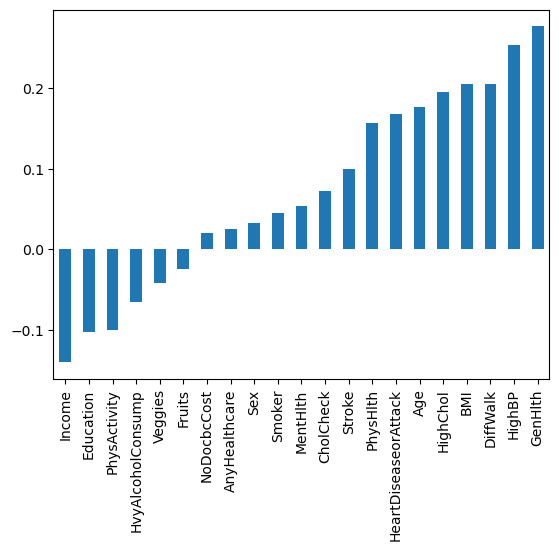

```python
df.corr()['Diabetes'][:-1].sort_values().plot(kind='bar')
```

Vemos el porcentaje de la gente con diabetes de la encuesta

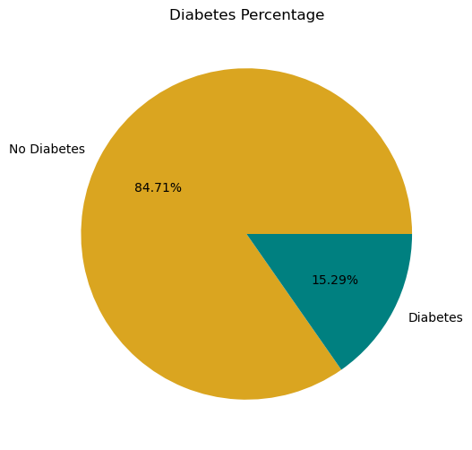

```python
plt.figure(figsize=(10,6))
plt.pie(df['Diabetes'].value_counts(), labels=['No Diabetes', 'Diabetes'], autopct='%1.2f%%', colors=['goldenrod', 'teal'])
plt.title('Diabetes Percentage')
plt.show()
```

Correlacion entre diabetes y edad

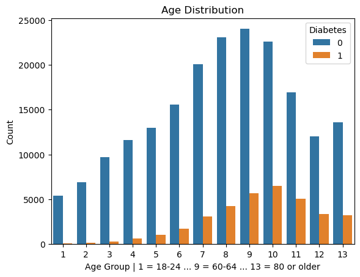

```python
sns.countplot(x='Age', data=df, hue='Diabetes')
plt.title('Age Distribution')
plt.xlabel('Age Group | 1 = 18-24 ... 9 = 60-64 ... 13 = 80 or older')
plt.ylabel('Count')
plt.show()
```

Al observar la grafica podemos observar que existe una relacion entre la edad y la diabetes, dando como resultado de que la gente mayor es mas propensa a sufrir diabetes

A continuacion separamos solo la poblacion de gente con diabetes para corrrelacionar esto con los sexos de las personas, para obvservar si existe una correlacion entre el sexo y la diabetes

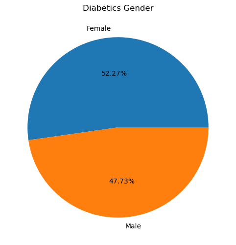

```python
Diabetics = df.where(df.Diabetes == 1)
Diabetics.dropna(inplace=True)

plt.figure(figsize=(10,6))
plt.pie(Diabetics['Sex'].value_counts(), labels=['Female','Male'] , autopct='%1.2f%%')
plt.title('Diabetics Gender')
plt.show()
```

En la grafica pasada se observa que no existe una correlacion fuerte entre el sexo y la diabetes como tal

A continuacion repetimos la misma corelacion con la gente de alto coresterol y la gente diabetica

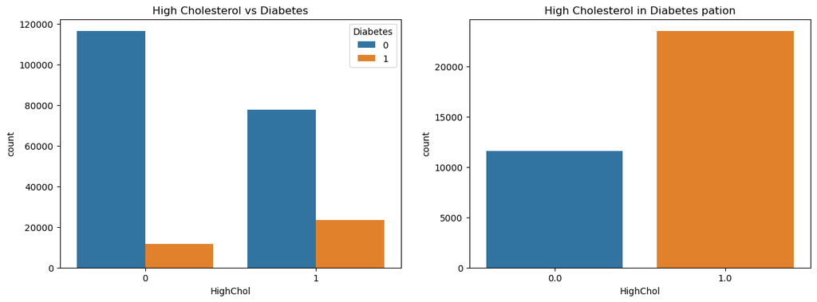

```python
fig,ax = plt.subplots(1,2,figsize=(15,5))
sns.countplot(x='HighChol', data=df, hue='Diabetes', ax=ax[0]).set_title('High Cholesterol vs Diabetes')
sns.countplot(x='HighChol', data=Diabetics, ax=ax[1]).set_title('High Cholesterol in Diabetes pation')
```

En la grafica podemos observar como la gente con colesterol alto tiente a tener diabetes en una medida mucho mayor que aquellos que no cuentan con coresterol alto.

En la grafica de la izquierda observamos toda la poblacion con y sin diabetes pero con colesterol alto, y en la grafica de la derecha solo observamos la correlacion de gente ya con diabetes y colesterol alto

Diabeticos con colesterol alto 23496

Diabeticos sin el colesterol alto 11601

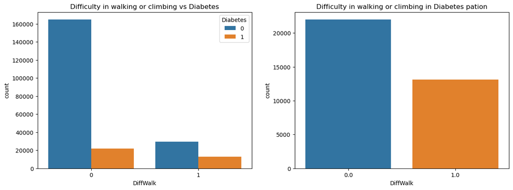

```python
fig,ax = plt.subplots(1,2,figsize=(15,5))
sns.countplot(x='DiffWalk', data=df, hue='Diabetes', ax=ax[0]).set_title('Difficulty in walking or climbing vs Diabetes')
sns.countplot(x='DiffWalk', data=Diabetics, ax=ax[1]).set_title('Difficulty in walking or climbing in Diabetes pation')
```

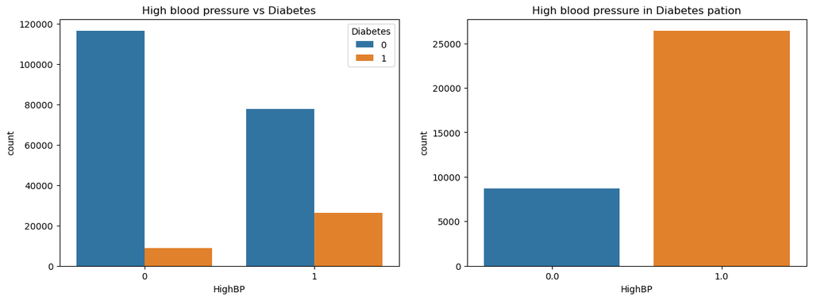

```python
fig,ax = plt.subplots(1,2,figsize=(15,5))
sns.countplot(x='HighBP', data=df, hue='Diabetes', ax=ax[0]).set_title('High blood pressure vs Diabetes')
sns.countplot(x='HighBP', data=Diabetics, ax=ax[1]).set_title('High blood pressure in Diabetes pation')
```

En las graficas enteriores podemos observar como la existencia de presion alta indica una mayor cantidad de poblacion con diabetes, dando como resultado los siguientes datos

Diabeticos con presion alta 26405

Diabeticos sin presion alta 8692

```
3.0    13324
4.0     9781
2.0     6280
5.0     4577
1.0     1135
Name: GenHlth, dtype: int64
```

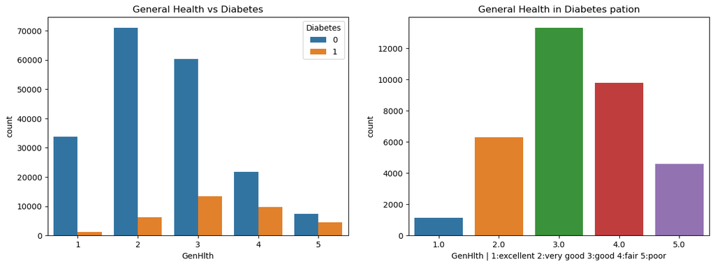

```python
fig,ax = plt.subplots(1,2,figsize=(15,5))
sns.countplot(x='GenHlth', data=df, hue='Diabetes', ax=ax[0]).set_title('General Health vs Diabetes')
sns.countplot(x='GenHlth', data=Diabetics, ax=ax[1]).set_title('General Health in Diabetes pation')
plt.xlabel('GenHlth | 1:excellent 2:very good 3:good 4:fair 5:poor')


Diabetics['GenHlth'].value_counts().sort_values(ascending=False)
```

Las graficas reflejan el como dependiendo de la percepcion de la salud general de las peresonas, la poblacion de la gente con diabetes crece de manera bastante clara

[output not shown]

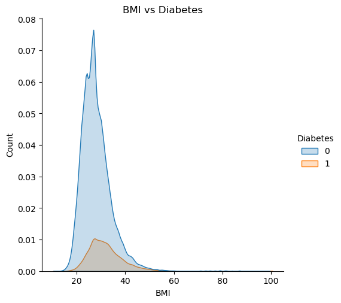

```python
sns.displot(df, x="BMI", hue="Diabetes", kind="kde", fill=True)
plt.title('BMI vs Diabetes')
plt.xlabel('BMI')
plt.ylabel('Count')
plt.show()
```

[figure not shown]

```python
fig,ax = plt.subplots(1,2,figsize=(15,5))
sns.boxplot(x='Diabetes', y='BMI', data=df, ax=ax[0]).set_title('BloodPressure vs Diabetes')
sns.violinplot(x='Diabetes', y='BMI', data=df, ax=ax[1]).set_title('BloodPressure vs Diabetes')
```

En las graficas podemos ver la densidad de la poblacion de los dataset, repartidos entre el indice de masa corporal y nuestra variable objetivo que es la diabetes

En la primer grafica podemos ver el estimado de la funcion de probabilidad del indice de masa corporal y de la existencia de diabetes en un rango de la misma

EN la segunda gfrafica de tipo boxplot podemos ver la densidad de cada uno de los grupos dentro de el indice de masa corporal donde observamos que existe un incremento significativo de personas que sufren diabetes dentro del espectro mas grande del indice de masa corporal, dando asi la correlacion entre ambas variables

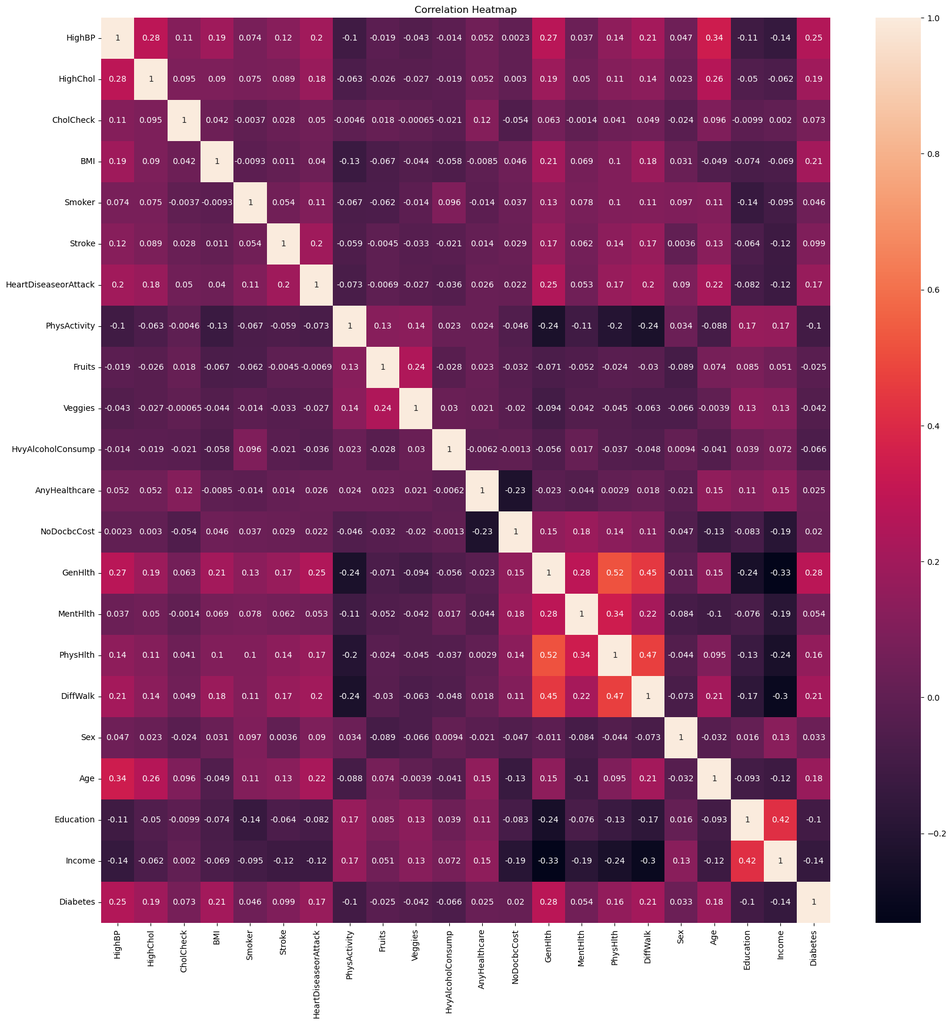

```python
plt.figure(figsize=(20,20))
sns.heatmap(df.corr(), annot=True).set_title('Correlation Heatmap')
```

En el mapa de calor de correlaciones podemos observar el como el crecimiento de una variable afecta en un porcentaje la probabilidad de la existencia de diabetes en una persona, donde los valores positivos hace referencia a el crecimiento por unidad de una variable con respecto a otra, mientras que los valores positivos hacen referencia a lo opuesto, es decir, que en cuanto una crece la otra decrece

```python
X_train, X_test, y_train, y_test = train_test_split(df.drop('Diabetes', axis=1), df['Diabetes'], test_size=0.2, random_state=42)
```

```python
solver = ['lbfgs', 'liblinear', 'newton-cg', 'sag', 'saga']
best_slover = ''
train_score = np.zeros(6)
for i, n in enumerate(solver):
    lr = LogisticRegression(solver=n).fit(X_train, y_train)
    train_score[i] = lr.score(X_test, y_test)
    if lr.score(X_test, y_test) == train_score.max():
        best_slover = n

lr = LogisticRegression(solver=best_slover)
lr.fit(X_train, y_train)
lr_pred = lr.predict(X_test)
print(best_slover)
print(f'LogisticRegression Score: {accuracy_score(y_test, lr_pred)}')
```

```
saga
LogisticRegression Score: 0.849373570105676
```

Creamos un data set de entrenamiento y entrenamos al modelo utilizando el dataset antes creado, en el cual podemos observar que el modelo tiene una presicion del 84.94% aproximadamente

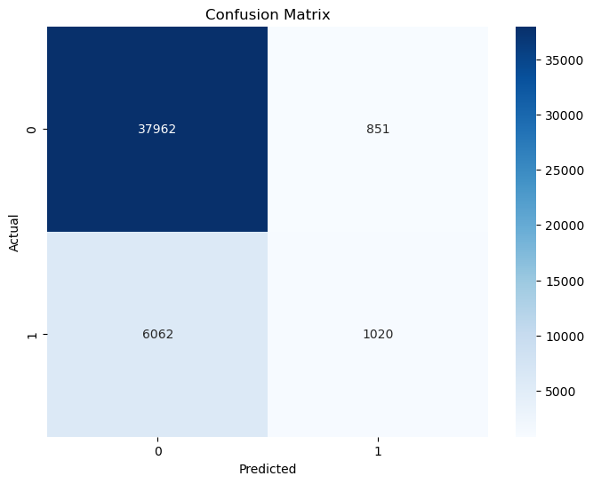

```python
cm = confusion_matrix(y_test, lr_pred)

# Plot confusion matrix
plt.figure(figsize=(8, 6))
sns.heatmap(cm, annot=True, fmt='d', cmap='Blues')
plt.xlabel('Predicted')
plt.ylabel('Actual')
plt.title('Confusion Matrix')
plt.show()
```

En la matiz de confusion observamos el comportamiento de la clasificacion de los datos, donde las casillas de tipo (0,0) y (1,1) nos dice las clasificaciones correctas del modelo

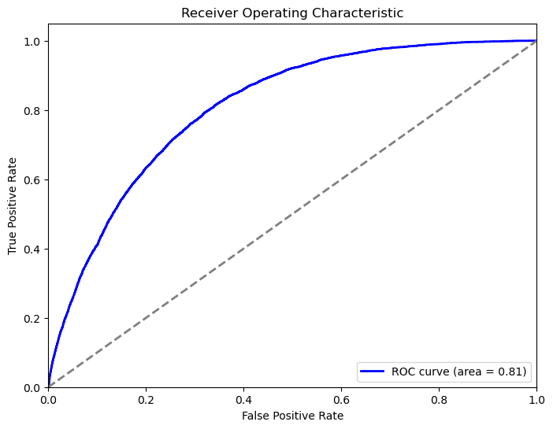

```python
from sklearn.metrics import roc_curve, auc
fpr, tpr, thresholds = roc_curve(y_test, lr.predict_proba(X_test)[:,1])

# Plot ROC curve
plt.figure(figsize=(8, 6))
plt.plot(fpr, tpr, color='blue', lw=2, label='ROC curve (area = %0.2f)' % auc(fpr, tpr))
plt.plot([0, 1], [0, 1], color='gray', lw=2, linestyle='--')
plt.xlim([0.0, 1.0])
plt.ylim([0.0, 1.05])
plt.xlabel('False Positive Rate')
plt.ylabel('True Positive Rate')
plt.title('Receiver Operating Characteristic')
plt.legend(loc='lower right')
plt.show()
```

La curva ROC es una gráfica que muestra el rendimiento de un modelo de clasificación en todos los umbrales de clasificación.

El eje X representa la Tasa de Falsos Positivos (1 - Especificidad) y el eje Y representa la Tasa de Verdaderos Positivos (Sensibilidad).

Una curva más cerca de la esquina superior izquierda indica un mejor rendimiento del modelo.

```
El área bajo la curva (AUC) es una métrica que cuantifica el rendimiento general del modelo, un AUC de 1.0 indica un modelo perfecto.
```